# COMPSCIX 415.2 Homework 7

Ganesh Saravanan

7/18/2018

## Exercise 1.

```r
train <- read.csv('~/Downloads/train.csv')
dim(train)
```

```
## [1] 1460   81
```

There are 1,460 observations and 81 columns.

## Exercise 2.

### 1. Visualize the distribution of SalePrice.

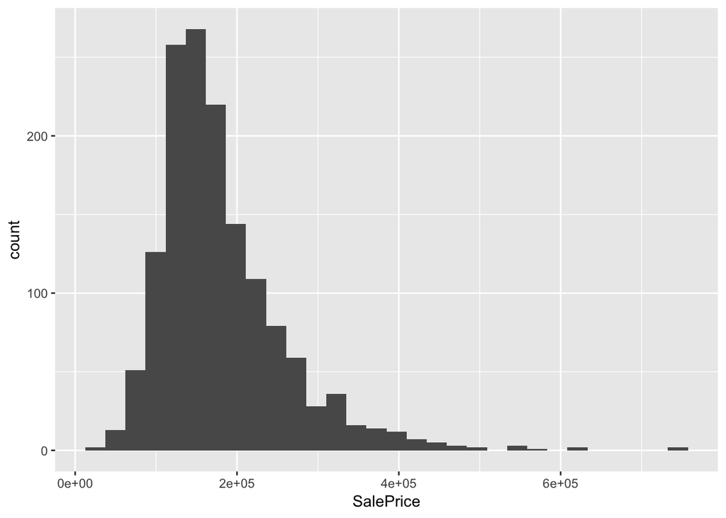

```r
library(ggplot2)
ggplot(data = train) + geom_histogram(aes(x = SalePrice))
```

### 2. Visualize the covariation between SalePrice and Neighborhood.

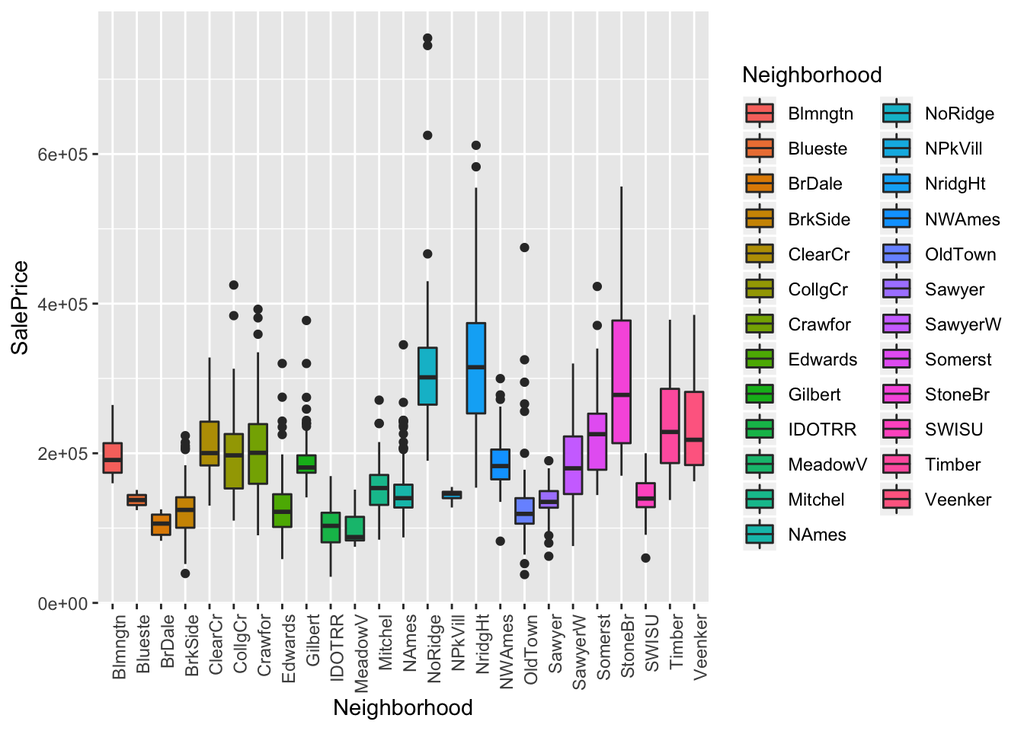

```r
ggplot(data = train, aes(x = Neighborhood, y = SalePrice)) +
  geom_boxplot(aes(fill= Neighborhood)) +
  theme(axis.text.x = element_text(angle = 90, hjust = 1))
```

### 3. Visualize the covariation between SalePrice and OverallQual.

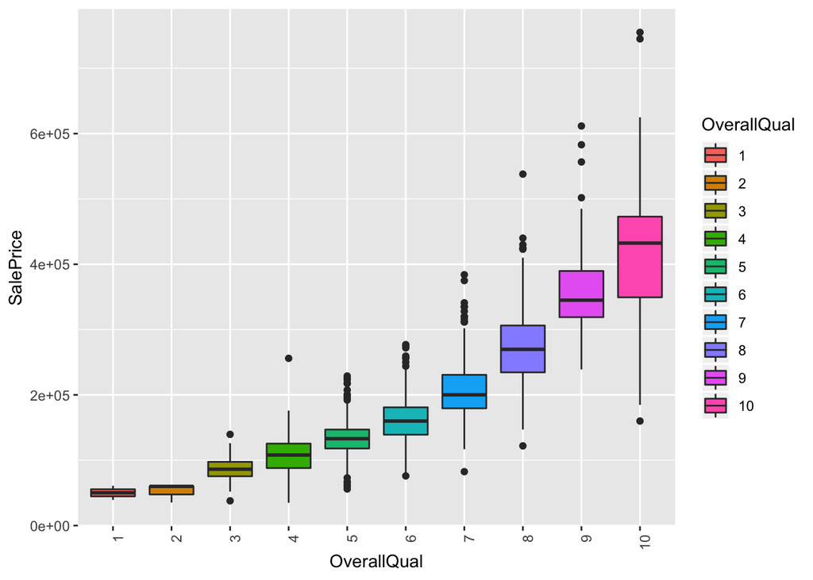

```r
train$OverallQual <- as.factor(train$OverallQual)
ggplot(data = train, aes(x = OverallQual, y = SalePrice)) +
  geom_boxplot(aes(fill= OverallQual)) +
  theme(axis.text.x = element_text(angle = 90, hjust = 1))
```

## Exercise 3.

```r
library(broom)
fit <- lm(SalePrice ~1 , data=train)
tidy(fit)
```

```
## # A tibble: 1 x 5
##   term        estimate std.error statistic p.value
##   <chr>          <dbl>     <dbl>     <dbl>   <dbl>
## 1 (Intercept)  180921.     2079.      87.0       0
```

The coefficient is 180921.2

```r
mean(train$SalePrice)
```

```
## [1] 180921.2
```

The coefficient is the same as the average value of SalePrice.

```r
glance(fit)
```

```
## # A tibble: 1 x 11
##   r.squared adj.r.squared  sigma statistic p.value    df  logLik    AIC
##       <dbl>         <dbl>  <dbl>     <dbl>   <dbl> <int>   <dbl>  <dbl>
## 1         0             0 79443.        NA      NA     1 -18544. 37092.
## # ... with 3 more variables: BIC <dbl>, deviance <dbl>, df.residual <int>
```

R-square is 0.

## Exercise 4

```r
# Now fit a linear regression model using GrLivArea, OverallQual, and Neighborhood as the features.
options(tibble.print_max = Inf)
fit2 <- lm(data = train, SalePrice ~ GrLivArea + OverallQual+ Neighborhood)
tidy(fit2)
```

```
## # A tibble: 35 x 5
##    term                 estimate std.error statistic  p.value
##    <chr>                   <dbl>     <dbl>     <dbl>    <dbl>
##  1 (Intercept)           45937.   26077.      1.76   7.84e- 2
##  2 GrLivArea                51.4      2.37   21.6    4.37e-90
##  3 OverallQual2          12400.   31687.      0.391  6.96e- 1
##  4 OverallQual3          16129.   25701.      0.628  5.30e- 1
##  5 OverallQual4          31128.   24742.      1.26   2.09e- 1
##  6 OverallQual5          39348.   24643.      1.60   1.11e- 1
##  7 OverallQual6          50280.   24695.      2.04   4.19e- 2
##  8 OverallQual7          69264.   24831.      2.79   5.35e- 3
##  9 OverallQual8         105024.   25044.      4.19   2.92e- 5
## 10 OverallQual9         182432.   25645.      7.11   1.78e-12
## 11 OverallQual10        213488.   26623.      8.02   2.20e-15
## 12 NeighborhoodBlueste  -30255.   25944.     -1.17   2.44e- 1
```

[output cut: 23 more lines]

- How would you interpret the coefficients on GrLivArea and OverallQual?

GrLivArea and OverallQual are positive related to SalePrice. For 1 unit increases in GrLivArea, the SalePrice will increase $51.37. For OverallQual, when the rating increases, the SalePrice increases as wel.

- How would you interpret the coefficient on NeighborhoodBrkSide?

NeighborhoodBrkSide is negative related to SalePrice. If the house is at NeighborhoodBrkSide, the SalePrice will be lower by 23951.

- Are the features significant?

GrLivArea is statistical significant. OverallQual rating from 6-10 are significant while the others are not. Some neighborhoods are significant to the SalePrice while some are not.

- Are the features practically significant?

Yes they are practically significant.

- Is the model a good fit?

```r
glance(fit2)
```

```
## # A tibble: 1 x 11
##   r.squared adj.r.squared  sigma statistic p.value    df  logLik    AIC
## *     <dbl>         <dbl>  <dbl>     <dbl>   <dbl> <int>   <dbl>  <dbl>
## 1     0.816         0.812 34489.      186.       0    35 -17309. 34689.
## # ... with 3 more variables: BIC <dbl>, deviance <dbl>, df.residual <int>
```

The Adjusted R-squared is 0.8115, I think it provides a good fit.

## Exercise 6

```r
library(tibble)
sim1a <- tibble(
x = rep(1:10, each = 3),
y = x * 1.5 + 6 + rt(length(x), df = 2)
)

fit_sim <- lm(data = sim1a, y~x)
tidy(fit_sim)
```

```
## # A tibble: 2 x 5
##   term        estimate std.error statistic  p.value
##   <chr>          <dbl>     <dbl>     <dbl>    <dbl>
## 1 (Intercept)     7.49    0.488       15.4 3.59e-15
## 2 x               1.29    0.0786      16.4 6.50e-16
```

```r
glance(fit_sim)
```

```
## # A tibble: 1 x 11
##   r.squared adj.r.squared sigma statistic  p.value    df logLik   AIC   BIC
## *     <dbl>         <dbl> <dbl>     <dbl>    <dbl> <int>  <dbl> <dbl> <dbl>
## 1     0.906         0.903  1.24      270. 6.50e-16     2  -47.9  102.  106.
## # ... with 2 more variables: deviance <dbl>, df.residual <int>
```

```r
intercept_list <- rep(NA, 6)
coef_list <- rep(NA,6)
rsquare_list <- rep(NA,6)
adj_rsquare_list <- rep(NA,6)
for(i in 1:6){
    sim1a <- tibble(
  x = rep(1:10, each = 3),
  y = x * 1.5 + 6 + rt(length(x), df = 2)
  )

fit_sim <- lm(data = sim1a, y~x)
intercept_list[i] <- tidy(fit_sim)$estimate[1] # the estimate of intercept
coef_list[i] <- tidy(fit_sim)$estimate[2] # the estimate of coefficent for x
rsquare_list[i] <- glance(fit_sim)$r.squared # r square
adj_rsquare_list[i] <- glance(fit_sim)$adj.r.squared # adjusted r square

}
```

Rerun the simulated data 6 times, here is the coefficent for x:

```r
coef_list
```

```
## [1] 1.503966 1.586087 1.346133 1.507460 1.668959 1.639221
```

Here is the rsquare:

```r
rsquare_list
```

```
## [1] 0.9437533 0.9155249 0.8473576 0.8437383 0.4921597 0.8280311
```

We can see that the coefficent fluctuates around 1.5 and the rsquare varies a lot. Sometimes it provides a good fit, sometimes it does not.